# Proyecto Final - Parte 3

Alsea, S.A.B. de C.V. (ALSEA.MX)

Nicole Getzabel Flores Godínez

Andrea Gutiérrez Rentería

Isaac Emiliano Meza López

María Fernanda Gómez Flores

# 1 Introducción

En las dos primeras entregas analizamos el comportamiento histórico del precio de Alsea, identificando los periodos en los que tuvo cambios importantes y relacionándolos con distintos eventos económicos, políticos y de la propia empresa. En esta tercera entrega buscamos ir un paso más allá, analizando si el comportamiento de los rendimientos de Alsea cumple con los supuestos estadísticos que se utilizan en los modelos financieros.

Para esto, trabajamos con el modelo de Movimiento Browniano Geométrico (GBM), que se utiliza para modelar cómo puede cambiar el precio de un activo financiero a lo largo del tiempo. Este modelo supone que los rendimientos logarítmicos siguen una distribución normal y que su media y volatilidad se mantienen constantes. Estos supuestos son importantes porque se utilizan para estimar el comportamiento futuro de los precios y calcular medidas de riesgo, como el Valor en Riesgo (VaR).

El análisis se divide en cinco partes. Primero, calculamos los rendimientos logarítmicos de Alsea y estimamos su media y volatilidad para todo el periodo y para cada año, con el objetivo de observar cómo han cambiado estos valores con el tiempo. Después, aplicamos las pruebas estadísticas de Jarque-Bera y t para evaluar si los rendimientos siguen una distribución normal y si su media es significativamente diferente de cero.

Posteriormente, utilizamos los parámetros obtenidos para simular posibles trayectorias del precio de Alsea mediante el modelo GBM. Realizamos simulaciones con parámetros diarios para horizontes de 10, 20 y 40 días, y con parámetros anualizados para periodos de 3, 6, 9 y 12 meses. En ambos casos, incluimos intervalos de confianza para observar los posibles rangos de precios que plantea el modelo. Por último, analizamos qué tan adecuado es asumir que los rendimientos siguen una distribución normal y qué implicaciones puede tener esto al evaluar el riesgo de la acción.

Con este análisis buscamos no solo obtener resultados estadísticos y realizar simulaciones, sino también entender qué nos dicen sobre el comportamiento de Alsea y qué tan bien se ajusta el modelo GBM a sus datos históricos. De esta manera, podemos identificar las limitaciones del modelo y comprender por qué sus resultados deben interpretarse considerando la incertidumbre y los riesgos que existen en el mercado real.

# 2 Cálculo de rendimientos y volatilidad

## 2.1 Descarga de datos

```
## [1] "ALSEA.MX"
```

```
##             Precio
## 2000-01-18 1.97286
## 2000-01-19 1.97286
## 2000-01-20 1.97286
## 2000-01-21 1.97286
## 2000-01-24 1.97286
## 2000-01-25 1.97286
```

```
##            Precio
## 2026-10-07  46.90
## 2026-10-08  47.64
## 2026-10-09  48.48
## 2026-10-12  48.62
## 2026-10-13  49.56
## 2026-10-14  49.79
```

## 2.2 Rendimiento logarítmico diario

Calculamos el rendimiento logarítmico diario de la misma forma en que lo hicimos en la Parte 2, porque es el rendimiento que vamos a usar en todo el análisis estadístico y en la construcción del modelo GBM:

$$r_t=\ln\left(\frac{P_t}{P_{t-1}}\right)$$

```
##        Fecha Rendimiento
## 1 2000-01-19           0
## 2 2000-01-20           0
## 3 2000-01-21           0
## 4 2000-01-24           0
## 5 2000-01-25           0
## 6 2000-01-26           0
```

```
##           Fecha Rendimiento
## 6778 2026-10-07 0.013523895
## 6779 2026-10-08 0.015655024
## 6780 2026-10-09 0.017478601
## 6781 2026-10-12 0.002883615
## 6782 2026-10-13 0.019149138
## 6783 2026-10-14 0.004630095
```

## 2.3 Estimaciones utilizando toda la información disponible

Para esta parte utilizamos los datos de 2021 a 2025, manteniendo el mismo periodo que en el resto del documento para que los resultados sean comparables. Además, al final de esta sección incorporamos una actualización con la información disponible de 2026, con el fin de complementar el análisis con el comportamiento observado durante el año en curso. A partir de los rendimientos diarios, calculamos la media y la volatilidad, tanto diaria como anualizada. La media nos permite conocer el rendimiento promedio de la acción, mientras que la volatilidad nos ayuda a medir qué tanto varían sus rendimientos. Esto es importante porque una volatilidad más alta indica que los rendimientos presentan mayores fluctuaciones. Para obtener los valores anuales, utilizamos 252 días hábiles, que es la cantidad que normalmente se considera para un año bursátil.

```
##   Rendimiento_promedio_diario Volatilidad_diaria Rendimiento_promedio_anual
## 1                0.0006059885          0.0192921                  0.1527091
##   Volatilidad_anual
## 1         0.3062526
```

Las fórmulas que utilizamos son:

$$\hat{\mu}_{diario}=\frac{1}{n}\sum_{t=1}^{n}r_t$$

$$\hat{\sigma}_{diario}=\sqrt{\frac{1}{n-1}\sum_{t=1}^{n}(r_t-\hat{\mu}_{diario})^2}$$

Para anualizar los resultados:

$$\hat{\mu}_{anual}=\hat{\mu}_{diario}\times252$$

$$\hat{\sigma}_{anual}=\hat{\sigma}_{diario}\times\sqrt{252}$$

La media se anualiza multiplicándola por 252, mientras que para la volatilidad utilizamos la raíz cuadrada de 252. La anualización de la media es lineal porque los rendimientos logarítmicos son aditivos en el tiempo (la suma de rendimientos diarios da el rendimiento del periodo). La volatilidad, en cambio, se anualiza con la raíz cuadrada del número de periodos porque la varianza de una suma de rendimientos independientes es la suma de las varianzas, y la desviación estándar es la raíz cuadrada de la varianza.

## 2.4 Estimaciones año por año

Además de analizar todo el periodo en conjunto, calculamos la media y la volatilidad para cada año, de 2021 a 2025. La idea es comparar los resultados y observar si el comportamiento de los rendimientos ha sido similar o si existen diferencias importantes entre los años.

Esto nos ayuda a identificar si la volatilidad se ha mantenido relativamente estable o si ha aumentado o disminuido en ciertos periodos. También podemos observar cómo cambia el rendimiento promedio anualizado, aunque este puede variar bastante de un año a otro.

```
##   Anio Rendimiento_promedio_diario Volatilidad_diaria
## 1 2021                0.0015115124         0.02007859
## 2 2022               -0.0001242670         0.02037676
## 3 2023                0.0022286164         0.01590529
## 4 2024               -0.0014859027         0.01828944
## 5 2025                0.0008956773         0.02126331
##   Rendimiento_promedio_anual Volatilidad_anual
## 1                 0.38090113         0.3187378
## 2                -0.03131529         0.3234711
## 3                 0.56161133         0.2524886
## 4                -0.37444747         0.2903359
## 5                 0.22571069         0.3375446
```

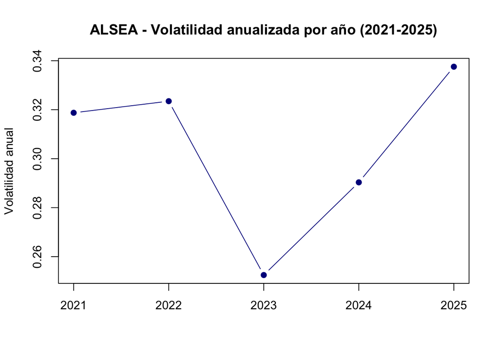

Esto se relaciona con lo que analizamos en la segunda entrega, donde identificamos una etapa de recuperación después de la pandemia y un comportamiento menos favorable en el periodo más reciente. En particular, 2024 destaca por tener el rendimiento promedio más bajo de los cinco años, lo que nos ayuda a identificar en qué año se presentó el deterioro más importante. En general, estos resultados muestran que, aunque la volatilidad no presenta cambios tan grandes entre años, los rendimientos sí pueden variar considerablemente, algo importante para evaluar el riesgo de invertir en Alsea. A partir de estas estimaciones no observamos un cambio estructural evidente en la volatilidad durante el periodo, aunque este análisis es descriptivo y no constituye una prueba formal de cambio estructural.

### 2.4.1 Actualización con información disponible de 2026

Adicionalmente, incorporamos la información disponible de 2026 mediante una actualización separada. Debido a que 2026 todavía no es un año completo, estos resultados se presentan de forma complementaria y no se comparan directamente con los años completos anteriores.

```
##   Rendimiento_promedio_diario Volatilidad_diaria Rendimiento_promedio_anual
## 1                0.0004809261          0.0189387                  0.1211934
##   Volatilidad_anual
## 1         0.3006425
```

```
##             Anio Rendimiento_promedio_diario Volatilidad_diaria
## 1 2026 (parcial)               -0.0003176957         0.01652616
##   Rendimiento_promedio_anual Volatilidad_anual
## 1                -0.08005931         0.2623446
```

# 3 Pruebas estadísticas

En esta sección evaluamos si los datos de Alsea cumplen los supuestos del modelo GBM. Para que los resultados sean comparables con la sección anterior, utilizamos el mismo periodo, de 2021 al último día de cotización de 2025.

## 3.1 Pruebas de normalidad (Jarque-Bera)

La prueba de Jarque-Bera compara la asimetría y la curtosis de una serie con las de una distribución normal, que tiene asimetría igual a 0 y curtosis igual a 3. El estadístico es:

$$JB=\frac{n}{6}\left(S^2+\frac{(K-3)^2}{4}\right)$$

donde $n$ es el número de observaciones, $S$ es la asimetría y $K$ es la curtosis. Bajo la hipótesis nula, $JB$ sigue una distribución $\chi^2$ con 2 grados de libertad. Las hipótesis son:

$$H_0: \text{la serie sigue una
distribución normal} \qquad H_1: \text{la serie no sigue una
distribución normal}$$

Si el p-valor es menor a 0.05, rechazamos la normalidad con un nivel de significancia del 5%.

Aplicamos la prueba a tres series: los rendimientos logarítmicos, el precio y el logaritmo natural del precio.

```
##                       Serie Observaciones  Asimetria Curtosis Exceso_curtosis
## 1 Rendimientos logarítmicos          1258  0.2313218 6.274989      3.27498895
## 2                    Precio          1258  0.2971227 2.730214     -0.26978639
## 3      Logaritmo del precio          1258 -0.3534310 3.081056      0.08105623
##   Estadistico_JB      p_valor            Conclusion
## 1      573.41693 0.000000e+00 Se rechaza normalidad
## 2       22.32490 1.419743e-05 Se rechaza normalidad
## 3       26.53457 1.730182e-06 Se rechaza normalidad
```

Para complementar la prueba, comparamos el histograma de cada serie con la curva de una distribución normal que tiene la misma media y desviación estándar.

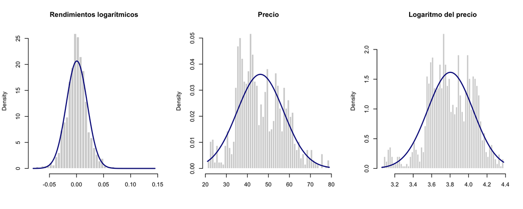

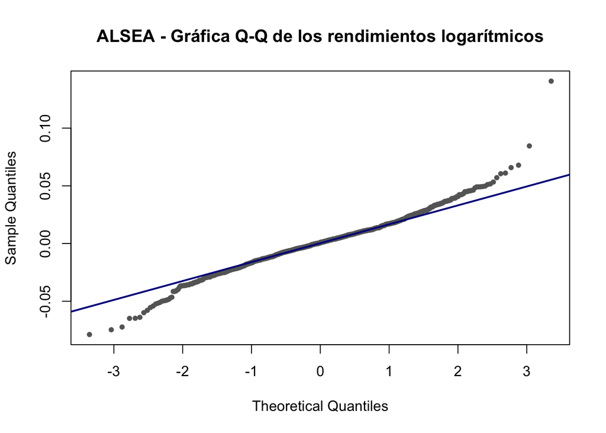

### 3.1.1 Interpretación de las pruebas de normalidad

**Rendimientos logarítmicos.** Los rendimientos tienen una asimetría de 0.231 y una curtosis de 6.275, lo que equivale a un exceso de curtosis de 3.275. El estadístico de Jarque-Bera es 573.42, con un p-valor de <2e-16, por lo que rechazamos la hipótesis de normalidad al 5%.

Una curtosis mayor a 3 indica que la distribución es **leptocúrtica**: tiene más observaciones cerca de la media y, sobre todo, **colas más pesadas** que la normal. En la gráfica Q-Q esto se ve porque los puntos de los extremos se alejan de la línea recta. En términos financieros, los días con movimientos muy grandes, tanto caídas como subidas, ocurren con más frecuencia de lo que predice la distribución normal. La asimetría positiva indica que la cola derecha es más larga, es decir, que las subidas extremas tienden a ser más fuertes que las caídas extremas.

Esto es importante para medir el riesgo: si suponemos normalidad, el modelo va a **subestimar la probabilidad de pérdidas grandes**, y medidas como el VaR calculado con la normal pueden ser menores que el riesgo real de la acción.

**Precio y logaritmo del precio.** Para el precio, la asimetría es 0.297 y la curtosis 2.73, con un p-valor de 1.42e-05. Para el logaritmo del precio, la asimetría es -0.353 y la curtosis 3.081, con un p-valor de 1.73e-06.

Estos resultados deben interpretarse con cuidado. La prueba de Jarque-Bera supone que las observaciones son independientes y vienen de la misma distribución, pero el precio no cumple esto: el precio de hoy depende directamente del precio de ayer y su nivel cambia con el tiempo (la serie no es estacionaria). Por eso, el histograma del precio refleja más bien **la trayectoria que siguió Alsea** en estos cinco años (los niveles en los que se mantuvo más tiempo) que una distribución de probabilidad.

Además, el modelo GBM no dice que la serie histórica de precios deba ser normal. Lo que dice es que, para un horizonte fijo $T$, el logaritmo del precio futuro $\ln S_T$ sigue una distribución normal entre todos los escenarios posibles, y que el precio $S_T$ sigue una distribución lognormal. Por lo tanto, la prueba relevante para evaluar el supuesto del GBM es la de los **rendimientos logarítmicos**, no la de los niveles de precio.

## 3.2 Prueba de media igual a cero

Para saber si el rendimiento promedio diario es estadísticamente distinto de cero, aplicamos una prueba t con las siguientes hipótesis:

$$H_0: \mu_r = 0 \qquad H_1: \mu_r \neq
0$$

El estadístico de prueba es:

$$t=\frac{\bar{r}}{s/\sqrt{n}}$$

donde $\bar{r}$ es el rendimiento promedio diario, $s$ es la desviación estándar diaria y $n$ es el número de observaciones.

```
##   Media_diaria Error_estandar Estadistico_t Grados_libertad   p_valor
## 1 0.0006059885   0.0005439252      1.114102            1257 0.2654482
##   IC95_inferior IC95_superior
## 1 -0.0004611129    0.00167309
```

```
## [1] 0.2689096
```

El estadístico t es 1.114, con un p-valor de 0.2654. Por lo tanto, no rechazamos la hipótesis nula: no hay evidencia estadística de que el rendimiento promedio diario de Alsea sea distinto de cero al 5%. El intervalo de confianza al 95% para la media diaria va de -0.0461% a 0.1673%.

Este resultado se explica por la diferencia de tamaño entre la media y la volatilidad. La media diaria es de apenas 0.0606%, mientras que la volatilidad diaria es de 1.93%. Con los 1258 días de datos que tenemos, la media anualizada tendría que ser mayor a aproximadamente 26.89% en valor absoluto para ser estadísticamente significativa. Esto también explica por qué en la sección anterior los rendimientos anuales cambiaron tanto de un año a otro: con una volatilidad tan alta, la media de un solo año se estima con muy poca precisión.

## 3.3 Interpretación: eficiencia de mercado y consistencia con la teoría

La hipótesis de mercados eficientes en su forma débil dice que los precios ya reflejan toda la información de los precios pasados, por lo que no debería ser posible predecir los rendimientos de mañana con los rendimientos de hoy. Para complementar la prueba t, aplicamos la prueba de Ljung-Box, que evalúa si existe autocorrelación en los primeros 10 rezagos de una serie. La aplicamos a los rendimientos y a los rendimientos al cuadrado.

```
##                      Serie Estadistico_Q     p_valor
## 1             Rendimientos      4.031998 0.945891939
## 2 Rendimientos al cuadrado     23.301277 0.009687512
```

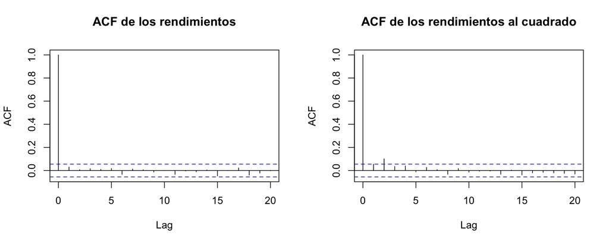

**Eficiencia de mercado.** El resultado de la prueba t es consistente con la idea de que no hay un rendimiento diario sistemático que un inversionista pueda aprovechar. Sin embargo, una media igual a cero por sí sola no demuestra que el mercado sea eficiente, ya que un mercado eficiente también puede tener una media positiva como compensación por el riesgo. La prueba más directa es la de autocorrelación. Para los rendimientos, el p-valor de Ljung-Box es 0.9459, por lo que no encontramos autocorrelación significativa: los rendimientos pasados no ayudan a predecir los futuros, lo que es consistente con la eficiencia de mercado en su forma débil.

**Consistencia con la teoría.** Los resultados confirman parcialmente los supuestos del GBM:

- **Rendimientos impredecibles:** se cumple, porque no detectamos autocorrelación en los rendimientos.
- **Rendimientos normales:** no se cumple. La prueba de Jarque-Bera rechaza la normalidad y la curtosis muestra colas más pesadas que la normal.
- **Volatilidad constante:** para los rendimientos al cuadrado, el p-valor de Ljung-Box es 0.00969. Como hay autocorrelación en los rendimientos al cuadrado, los días de alta volatilidad tienden a seguirse de otros días de alta volatilidad (agrupamiento de volatilidad). Esto contradice el supuesto de volatilidad constante y coincide con lo que vimos en la sección anterior, donde la volatilidad anual cambió de un año a otro.

En resumen, el GBM describe razonablemente el comportamiento promedio de Alsea, pero no captura las colas pesadas de sus rendimientos. Esto no significa que el modelo no sirva, sino que sus resultados deben verse como una aproximación que probablemente subestima la probabilidad de movimientos extremos.

# 4 Estimación del modelo con parámetros diarios

## 4.1 Ecuación del modelo

El modelo de Movimiento Browniano Geométrico describe el cambio del precio con la siguiente ecuación diferencial estocástica:

$$dS_t=\mu S_t\,dt+\sigma
S_t\,dW_t$$

donde $\mu$ es la tendencia (drift), $\sigma$ es la volatilidad y $dW_t$ es el incremento de un movimiento browniano, con $dW_t \sim N(0, dt)$. Aplicando el lema de Itô a $\ln S_t$ obtenemos la solución exacta del modelo:

$$S_T=S_0\exp\left[\left(\mu-\frac{\sigma^2}{2}\right)T+\sigma\sqrt{T}\,Z\right]
\qquad Z\sim N(0,1)$$

Como usamos parámetros diarios, $T$ se mide en días. Un punto importante es que la media de los rendimientos logarítmicos no estima $\mu$, sino $\mu-\sigma^2/2$, debido a la corrección de Itô. Por eso, el drift del modelo se obtiene como:

$$\hat{\mu}=\bar{r}+\frac{\hat{\sigma}^2}{2}$$

```
##     Fecha_S0       S0 Media_log_diaria Volatilidad_diaria Drift_GBM_diario
## 1 2025-12-31 53.00574     0.0006059885          0.0192921     0.0007920811
```

Usamos como valor inicial el último precio de cotización de 2025, $S_0=$ 53.01 pesos, del 31/12/2025. Sustituyendo los parámetros estimados, la ecuación del modelo para Alsea queda:

$$dS_t=7.92\times
10^{-4}\,S_t\,dt+0.019292\,S_t\,dW_t$$

y su solución:

$$S_T=53.01\exp\left[6.06\times
10^{-4}\,T+0.019292\sqrt{T}\,Z\right]$$

## 4.2 Precio esperado e intervalos de confianza

Como $\ln S_T$ sigue una distribución normal, podemos calcular el precio esperado y el intervalo al 95% de forma exacta:

$$E[S_T]=S_0e^{\mu T}$$

$$IC_{95\%}=\left[S_0\exp\left(\left(\mu-\frac{\sigma^2}{2}\right)T-1.96\,\sigma\sqrt{T}\right),\;S_0\exp\left(\left(\mu-\frac{\sigma^2}{2}\right)T+1.96\,\sigma\sqrt{T}\right)\right]$$

En sentido estricto, este es un intervalo de probabilidad para el precio futuro: indica el rango donde el modelo espera que se encuentre el precio en el 95% de los escenarios. También calculamos la probabilidad de que el precio termine por debajo de $S_0$:

$$P(S_T<S_0)=\Phi\left(\frac{-\left(\mu-\frac{\sigma^2}{2}\right)T}{\sigma\sqrt{T}}\right)$$

```
##   Horizonte_dias Precio_esperado  Mediana IC95_inferior IC95_superior Amplitud
## 1             10        53.42726 53.32793      47.31790      60.10131 12.78341
## 2             20        53.85212 53.65207      45.30513      63.53682 18.23169
## 3             40        54.71202 54.30627      42.75546      68.97766 26.22221
##   Amplitud_pct_S0 Prob_menor_S0
## 1       0.2411703     0.4604377
## 2       0.3439568     0.4441423
## 3       0.4947051     0.4212636
```

## 4.3 Procedimiento de simulación

Para comprobar los resultados anteriores, simulamos trayectorias del precio con el método de Monte Carlo. El procedimiento es el siguiente:

1. Fijamos una semilla (`set.seed`) para que los resultados se puedan reproducir.
2. Generamos 10,000 trayectorias de 40 días, todas empezando en $S_0$.
3. En cada día $t$ generamos un número aleatorio $Z_t \sim N(0,1)$ y calculamos el precio del día siguiente con la solución exacta del GBM para un paso de un día ($\Delta t=1$):
   $$S_{t+1}=S_t\exp\left[\left(\mu-\frac{\sigma^2}{2}\right)+\sigma
   Z_t\right]$$
4. Tomamos los precios simulados en los días 10, 20 y 40. Con ellos calculamos el precio promedio y los percentiles 2.5% y 97.5%, que forman el intervalo al 95%.
5. Comparamos los resultados simulados con los teóricos.

```
##   Horizonte_dias Precio_esperado_teorico Precio_esperado_simulado
## 1             10                53.42726                 53.43752
## 2             20                53.85212                 53.91896
## 3             40                54.71202                 54.78387
##   IC95_inf_teorico IC95_inf_simulado IC95_sup_teorico IC95_sup_simulado
## 1         47.31790          47.22947         60.10131          60.15527
## 2         45.30513          45.27160         63.53682          63.59299
## 3         42.75546          42.74169         68.97766          69.12528
```

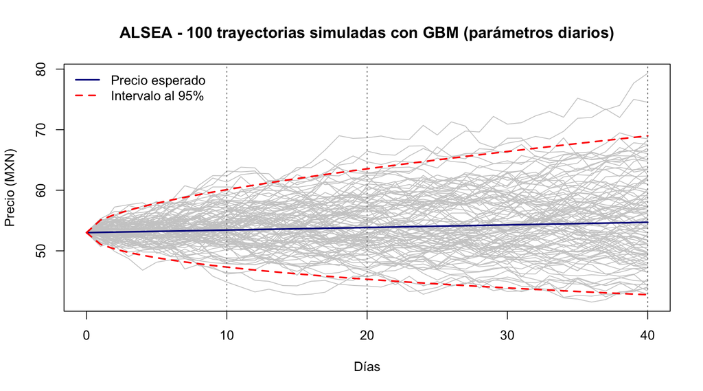

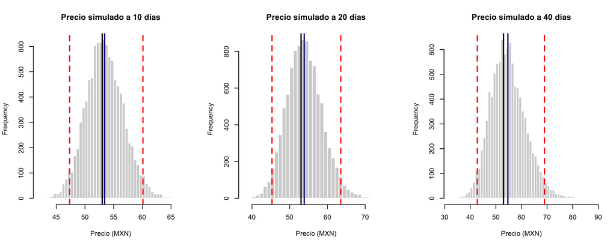

Los resultados de la simulación son muy cercanos a los teóricos, lo que confirma que el procedimiento es correcto. Las pequeñas diferencias se deben al error de muestreo de Monte Carlo y disminuirían si aumentamos el número de simulaciones.

## 4.4 Interpretación: incertidumbre en cada horizonte

A partir de un precio inicial de 53.01 pesos, el modelo estima los siguientes precios esperados:

- **10 días:** 53.43 pesos, con un intervalo al 95% de 47.32 a 60.1 pesos (amplitud de 24.1% del precio inicial).
- **20 días:** 53.85 pesos, con un intervalo de 45.31 a 63.54 pesos (amplitud de 34.4%).
- **40 días:** 54.71 pesos, con un intervalo de 42.76 a 68.98 pesos (amplitud de 49.5%).

**El precio esperado casi no cambia, pero la incertidumbre sí.** Como el drift diario es muy pequeño comparado con la volatilidad, el precio esperado a 40 días es apenas 3.22% distinto del precio inicial. En cambio, el ancho del intervalo crece considerablemente. Esto se debe a que la desviación estándar del rendimiento acumulado crece con la raíz del tiempo, $\sigma\sqrt{T}$: al cuadruplicar el horizonte de 10 a 40 días, la amplitud del intervalo aproximadamente se duplica (pasa de 12.78 a 26.22 pesos, una razón de 2.05). Es decir, la incertidumbre aumenta con el horizonte, pero cada vez a un ritmo menor.

**Los intervalos no son simétricos.** En los tres horizontes, la distancia entre el precio esperado y el límite superior es mayor que la distancia al límite inferior. Esto ocurre porque el precio sigue una distribución lognormal: no puede ser negativo, pero sí puede subir sin un límite superior. Por la misma razón, la mediana es menor que el precio esperado, ya que unos pocos escenarios muy favorables elevan el promedio.

**El riesgo de terminar abajo del precio inicial es alto.** La probabilidad de que el precio esté por debajo de $S_0$ es de 46% a 10 días, 44.4% a 20 días y 42.1% a 40 días. Estas probabilidades están cerca del 50%, lo que confirma que, en horizontes cortos, el movimiento del precio está dominado por la volatilidad y no por la tendencia.

**Limitaciones.** Estos intervalos suponen que los rendimientos son normales y que la volatilidad es constante. Sin embargo, en la sección anterior encontramos que los rendimientos de Alsea tienen colas más pesadas que la normal. Por lo tanto, es probable que el modelo subestime la probabilidad de que el precio termine fuera del intervalo, especialmente por caídas fuertes. En la práctica, los intervalos reales al 95% podrían ser más amplios que los que estima el GBM.

# 5 Estimación del modelo con parámetros anuales

Para trabajar con parámetros anualizados utilizamos:

$$\hat{\mu}_{GBM,anual}=\hat{\mu}_{log,anual}+\frac{1}{2}\hat{\sigma}_{anual}^2$$

Y para un horizonte $T$ expresado en años:

$$S_T=S_0\exp\left[\left(\hat{\mu}_{GBM,anual}-\frac{\hat{\sigma}_{anual}^2}{2}\right)T+\hat{\sigma}_{anual}\sqrt{T}Z\right]$$

con $T=3/12, 6/12, 9/12$ y $12/12$.

**Parámetros anuales**

```
##   Precio_inicial Media_log_anual Volatilidad_anual Drift_GBM_anual
## 1       53.00574       0.1527091         0.3062526       0.1996044
```

**Estimación para 3, 6, 9 y 12 meses**

```
##   Meses Precio_esperado IC95_inferior IC95_superior Amplitud
## 1     3           55.72         40.79         74.34    33.55
## 2     6           58.57         37.42         87.46    50.04
## 3     9           61.57         35.34         99.96    64.62
## 4    12           64.72         33.88        112.55    78.67
```

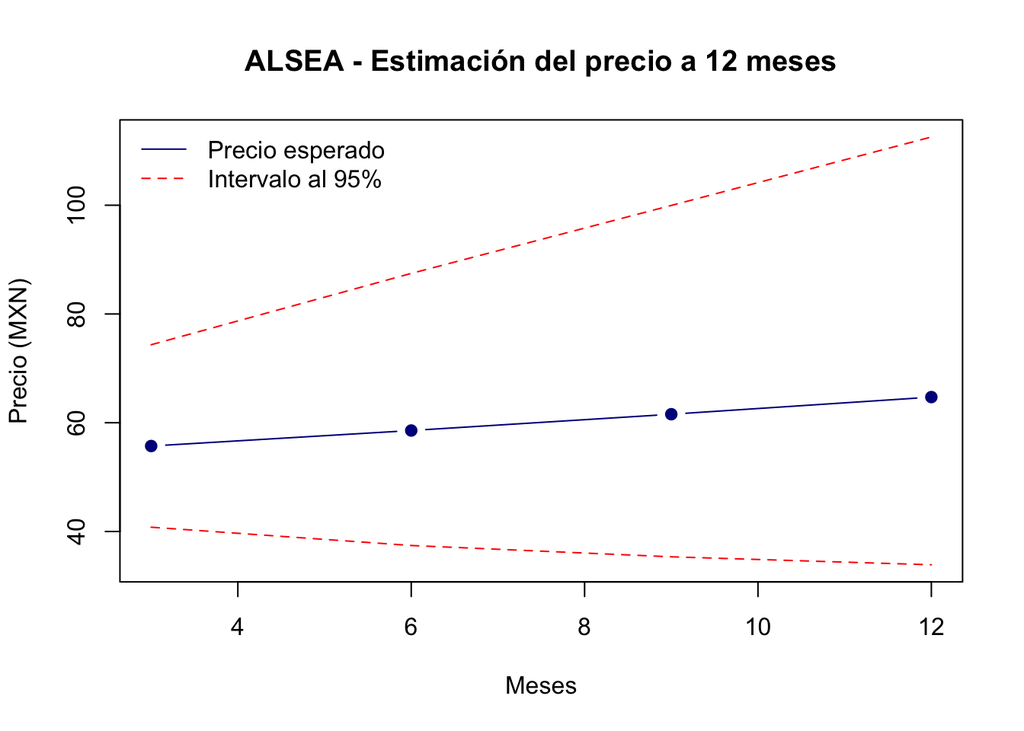

Al utilizar los parámetros anualizados de Alsea, podemos observar que el precio esperado aumenta conforme pasa el tiempo. A los 3 meses se estima un precio de $55.72, mientras que a los 12 meses aumenta a $64.72.

También observamos que la incertidumbre aumenta con el tiempo, ya que a los 3 meses el intervalo va de $40.79 a $74.34, mientras que a los 12 meses va de $33.88 a $112.55.

Esto nos indica que, aunque el modelo proyecta un aumento en el precio de la acción, las estimaciones a mayor plazo tienen más riesgo e incertidumbre.

# 6 Discusión teórica

### 6.0.1 ¿Los rendimientos siguen una distribución normal?

De acuerdo con el análisis de Jarque-Bera, los rendimientos de Alsea no se ajustan completamente a una distribución normal, ya que presentan colas más pesadas. Esto significa que pueden ocurrir movimientos extremos con mayor frecuencia de lo que supone una distribución normal.

### 6.0.2 ¿El precio es normal o lognormal?

Según el modelo GBM, el precio de las acciones sigue una distribución lognormal, mientras que el logaritmo del precio futuro sigue una distribución normal para un horizonte determinado. Esto tiene sentido porque los precios no pueden ser negativos, pero sí pueden aumentar considerablemente. Esto corresponde al supuesto teórico del GBM y no significa que la distribución histórica observada de los precios de Alsea sea perfectamente lognormal.

### 6.0.3 ¿Qué implicaciones tiene asumir normalidad en la modelación del riesgo?

Asumir normalidad facilita los cálculos y permite estimar precios futuros e intervalos de probabilidad. Sin embargo, también puede provocar que subestimemos el riesgo de movimientos extremos, especialmente cuando los rendimientos presentan colas pesadas.

### 6.0.4 ¿Qué diferencias se observan entre los supuestos teóricos del GBM y los datos reales?

El GBM supone que los rendimientos logarítmicos son normales y que la volatilidad es constante. Sin embargo, en los datos de Alsea observamos que existen movimientos extremos y que la volatilidad cambia entre los años analizados. Por lo tanto, el modelo es útil para realizar estimaciones, pero no representa perfectamente el comportamiento real del mercado.

### 6.0.5 ¿Qué riesgos puede introducir el supuesto de normalidad en la toma de decisiones financieras?

El principal riesgo es confiar demasiado en las estimaciones del modelo. Por ejemplo, a los 12 meses obtuvimos un precio esperado de $64.72, pero el intervalo al 95% va desde $33.88 hasta $112.55. Esto demuestra que existe mucha incertidumbre y que no debemos tomar decisiones de inversión considerando solamente el precio esperado.

# 7 Conclusión

En esta tercera entrega analizamos con mayor profundidad el comportamiento de los rendimientos de Alsea y comparamos los datos reales con los supuestos del modelo de Movimiento Browniano Geométrico. A partir de los resultados observamos que, aunque el GBM es útil para representar de manera sencilla la evolución del precio y generar posibles escenarios futuros, sus supuestos no se cumplen completamente en los datos reales de la acción.

Al analizar los rendimientos observamos que la volatilidad se mantiene en niveles relativamente cercanos entre los años, aunque existen diferencias. En cambio, los rendimientos anualizados cambian bastante de un año a otro, incluso alternando entre años positivos y negativos. Esto muestra que el comportamiento de la acción puede cambiar considerablemente aun cuando la volatilidad no presente cambios igual de grandes.

Las pruebas estadísticas también mostraron diferencias entre la teoría y los datos. La prueba de Jarque-Bera indicó que los rendimientos logarítmicos no siguen perfectamente una distribución normal y presentan colas más pesadas. Esto es importante porque significa que los movimientos extremos pueden ocurrir con mayor frecuencia de la que asumiría una distribución normal. Por otro lado, la prueba sobre la media diaria mostró que el rendimiento promedio es pequeño en comparación con la volatilidad, por lo que en horizontes cortos existe mucha incertidumbre alrededor del movimiento del precio.

Al utilizar el GBM para realizar las simulaciones observamos que el precio esperado cambia de forma relativamente moderada, pero los posibles resultados se vuelven mucho más dispersos conforme aumenta el horizonte. Esto se observa en los intervalos estimados, que se amplían conforme aumenta el tiempo. Por lo tanto, mientras más largo es el horizonte, mayor es la incertidumbre sobre el precio futuro.

En general, consideramos que el GBM es una herramienta útil para entender la relación entre rendimiento, volatilidad y tiempo, además de permitir generar escenarios de manera sencilla. Sin embargo, los resultados también muestran que no debe tomarse como una representación exacta del comportamiento del mercado. En el caso de Alsea, la falta de normalidad en los rendimientos, la presencia de movimientos extremos y los cambios en la volatilidad muestran que el riesgo real puede ser mayor al que representa el modelo.

Lo más importante que nos deja este análisis es que un modelo puede ser útil aunque no represente perfectamente la realidad, siempre que entendamos sus supuestos y limitaciones. Para analizar el riesgo no basta con observar un precio esperado, sino que también es necesario considerar la dispersión de los posibles resultados y la posibilidad de que ocurran eventos extremos. En este sentido, el GBM funciona como una referencia para estudiar el comportamiento del precio, pero las decisiones financieras deben considerar que la incertidumbre real del mercado puede ser mayor que la que el modelo supone.